# Six-sided die

Part of my CLT stress test. A population with zero skew, so what slows it down?

Author

Geonho Lee

Published

October 11, 2026

```r
source("clt_helpers.R")

student_id <- 5146
cutoff <- 0.3
```

## 1 The population

One roll of a fair die: the values 1 to 6, each with probability 1/6. The mean is 3.5 and the sd is about 1.71. It is perfectly symmetric, so skewness is 0, but it is flat instead of bell shaped. Its kurtosis is about 1.73 (excess kurtosis -1.27), so the tails are lighter than a normal. It is also discrete, like the binomial, the basketball shots and the ages in the life/death file, but it is the only one of those that is symmetric. The rolls are independent, all from the same distribution, and the variance is finite, so all three CLT assumptions hold.

```r
faces <- 1:6
pop_mean <- mean(faces)
# sd() would divide by 5, but this is the whole population so I divide by 6
pop_sd <- sqrt(mean((faces - pop_mean)^2))
pop_skew <- 0
pop_exkurt <- mean((faces - pop_mean)^4) / pop_sd^4 - 3

c(pop_mean = pop_mean, pop_sd = round(pop_sd, 3), pop_exkurt = round(pop_exkurt, 3))
```

```
  pop_mean     pop_sd pop_exkurt
     3.500      1.708     -1.269
```

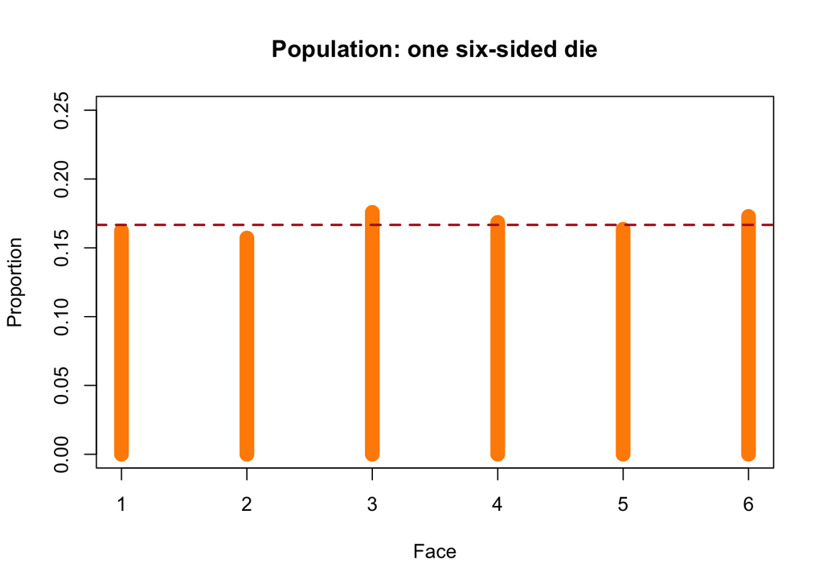

Share of each face in 10,000 rolls. Dashed line = 1/6.

```r
set.seed(student_id)
population_draws <- sample(faces, 10000, replace = TRUE)

plot(faces, as.numeric(table(population_draws)) / 10000, type = "h", lwd = 12,
     col = "darkorange", ylim = c(0, 0.25), xlab = "Face", ylab = "Proportion",
     main = "Population: one six-sided die")
abline(h = 1/6, col = "firebrick", lwd = 2, lty = 2)
```

## 2 What I expected before running anything

Skewness starts at 0, so it should never be the problem. The thing to watch is kurtosis. The excess kurtosis of the mean is -1.27/n, and to get that within 0.3 of zero I need n of about 4.2. So I predicted n = 5. That is way less than 30, but it is also not n = 2, even though the population has no skew at all.

```r
n_for_skew <- (pop_skew / cutoff)^2
n_for_kurt <- abs(pop_exkurt) / cutoff

c(n_for_skew = n_for_skew, n_for_kurt = n_for_kurt)
```

```
n_for_skew n_for_kurt
  0.000000   4.228571
```

## 3 Simulation

For each n I take 10,000 samples of n rolls and keep the mean of each sample. Same 51 values of n as the exponential file.

```r
sim <- run_simulation(
  generator = function(n) sample(faces, n, replace = TRUE),
  pop_sd = pop_sd,
  seed = student_id
)

results <- sim$results
```

## 4 What happens as n grows

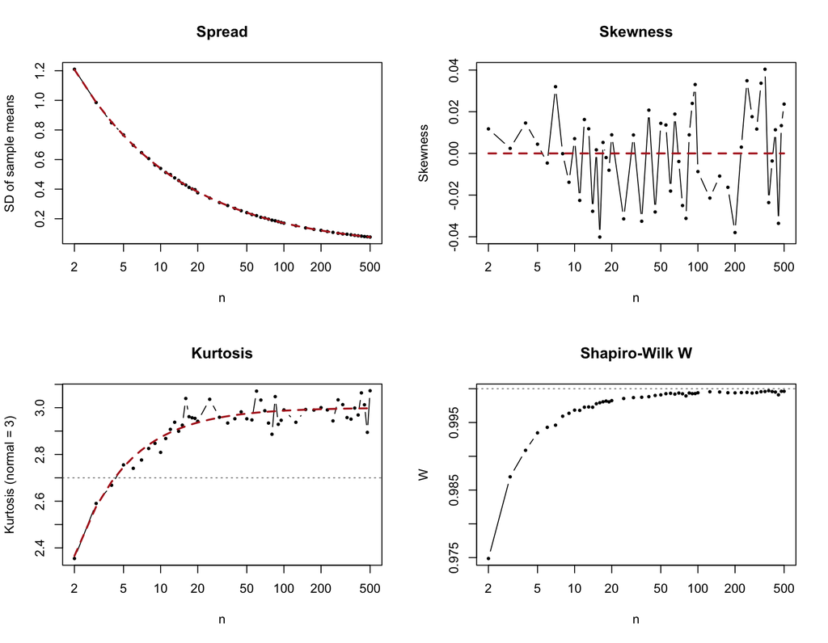

Red dashed = theory, gray dotted = my cutoff.

```r
plot_trends(results, pop_skew = pop_skew, pop_exkurt = pop_exkurt, cutoff = cutoff)
```

```r
show_rows <- results$n %in% c(2, 3, 4, 5, 6, 8, 10, 20, 30, 50, 100, 500)
knitr::kable(round(results[show_rows, ], 3), row.names = FALSE)
```

| n | mean | sd | theory_se | skewness | kurtosis | shapiro_w | sd_error |
| --- | --- | --- | --- | --- | --- | --- | --- |
| 2 | 3.521 | 1.210 | 1.208 | 0.012 | 2.355 | 0.975 | 0.002 |
| 3 | 3.477 | 0.985 | 0.986 | 0.002 | 2.590 | 0.987 | 0.001 |
| 4 | 3.498 | 0.848 | 0.854 | 0.015 | 2.668 | 0.991 | 0.007 |
| 5 | 3.498 | 0.767 | 0.764 | 0.004 | 2.755 | 0.993 | 0.004 |
| 6 | 3.505 | 0.696 | 0.697 | -0.005 | 2.741 | 0.994 | 0.002 |
| 8 | 3.506 | 0.607 | 0.604 | 0.000 | 2.825 | 0.996 | 0.005 |
| 10 | 3.503 | 0.540 | 0.540 | 0.007 | 2.809 | 0.997 | 0.000 |
| 20 | 3.504 | 0.375 | 0.382 | 0.009 | 2.942 | 0.998 | 0.018 |
| 30 | 3.500 | 0.310 | 0.312 | 0.009 | 2.959 | 0.999 | 0.007 |
| 50 | 3.498 | 0.241 | 0.242 | 0.014 | 2.953 | 0.999 | 0.001 |
| 100 | 3.500 | 0.170 | 0.171 | -0.009 | 2.991 | 0.999 | 0.002 |
| 500 | 3.500 | 0.077 | 0.076 | 0.024 | 3.073 | 1.000 | 0.003 |

```r
# checks over every n I tried, not just the rows above
c(max_mean_gap = round(max(abs(results$mean - pop_mean)), 3),
  max_sd_error = round(max(results$sd_error), 3),
  max_abs_skew = round(max(abs(results$skewness)), 3))
```

```
max_mean_gap max_sd_error max_abs_skew
       0.023        0.018        0.040
```

The mean is never more than 0.023 away from 3.5, and the sd is always within 2% of σ/√n (worst was 1.8%, at n = 20). Skewness never gets anywhere near my cutoff. The biggest value over every n was 0.04, which is why the gray cutoff lines do not even show up on the skewness plot. So kurtosis is the number that matters here. It starts at 2.35 at n = 2, too flat, and up to n = 5 it sits almost exactly on the red theory line. After that it bounces around the line by up to about 0.12 (the biggest jump is at n = 16), close to the 0.1 of noise I saw in the normal file. Shapiro W goes from 0.975 at n = 2 to 0.999 by n = 30.

## 5 A closer look

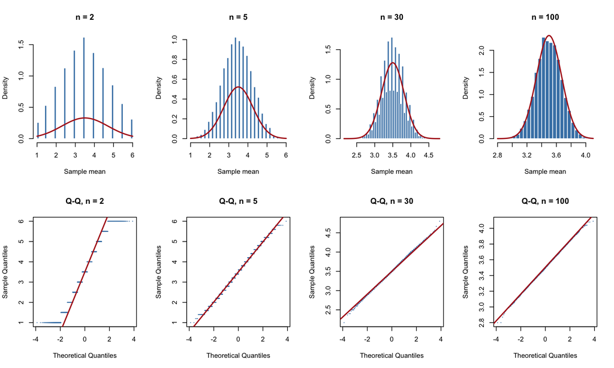

```r
chosen_n <- smallest_n(results, cutoff = cutoff)
plot_means(sim, show_n = c(2, chosen_n, 30, 100), pop_mean = pop_mean, pop_sd = pop_sd)
```

```r
# how many different values the sample mean actually takes
sapply(c("2", "5", "30"), function(k) length(unique(sim$means[[k]])))
```

```
 2  5 30
11 26 69
```

These plots look strange at first and it took me a minute to figure out why. With a die, the total of n rolls can only be a whole number, so the mean can only land on a few values. At n = 2 the mean only took 11 different values, at n = 5 it took 26, and at n = 30 it took 69. That is why the histograms at n = 2, 5 and 30 look like a comb with gaps, and the bars stick out above the red curve. The histogram bins just do not line up with those values. The shape itself is fine. By n = 100 the values are close enough together that the histogram fills in.

The Q-Q plots show the same thing as stairs. At n = 2 the steps are big and the ends go flat, because the mean cannot go below 1 or above 6. At n = 5 the steps are small and follow the line, except the last few points at each end bend in toward the middle. That is the light tails again (kurtosis is still 2.76 at n = 5), but it is small. For a discrete population the mean is never going to be truly smooth, so when I look at the Q-Q plot I am asking whether the stairs follow the line, not whether they disappear.

## 6 My decision

```r
chosen_n
```

```
[1] 5
```

My rule is the same in every file: skewness and kurtosis within 0.3 of a normal, sd within 3% of theory, and it has to keep passing for every bigger n. The smallest n that passes is **n = 5**. That matches my prediction exactly. n = 2, 3 and 4 fail only on kurtosis (2.35, 2.59 and 2.67), and at n = 5 it is 2.76.

Same data, different cutoff:

```r
data.frame(
  cutoff = c(0.5, 0.3, 0.2, 0.1, 0.05),
  smallest_n = sapply(c(0.5, 0.3, 0.2, 0.1, 0.05), function(k) smallest_n(results, cutoff = k))
)
```

```
  cutoff smallest_n
1   0.50          3
2   0.30          5
3   0.20          8
4   0.10        500
5   0.05         NA
```

From 0.5 down to 0.2 the answer only moves from 3 to 8. At 0.1 it jumps to 500, the last n I tried, and at 0.05 not even n = 500 passes (that is what the NA means). It is the same thing I found in the normal file. Below about 0.1, the cutoff is mostly catching simulation noise, not the die.

## 7 Does the seed matter?

```r
sim_167 <- run_simulation(
  generator = function(n) sample(faces, n, replace = TRUE),
  pop_sd = pop_sd,
  seed = 167
)
smallest_n(sim_167$results, cutoff = cutoff)
```

```
[1] 5
```

Seed 167 also gives n = 5. Unlike the exponential, the kurtosis curve crosses my cutoff steeply instead of creeping along it, so a different seed does not move the answer.

## 8 What surprised me

The main thing I would point out is that a population with zero skew still is not normal at n = 2. I knew kurtosis would be the number to watch, but if I had only checked skewness, the die would have passed right away. That is a good reason not to rely on one number. The other surprise was the comb-shaped histograms. They looked like a problem but were just the die being discrete, and the Q-Q plot made that much easier to see than the histogram did.